# Time Series - Final Project - Drug Analysis

Shashank Thakre, Nikhil Shakkarwar, Greg Younkie, Paloma Flores

5/1/2021

## Beer Sales - Drug Store Sales Analysis

Import Libraries

```r
library(TSA)
library(fpp)
library(tseries)
library(ggplot2)
library(forecast)
library(lubridate)
library(MTS)
library(vars)
```

Load the file

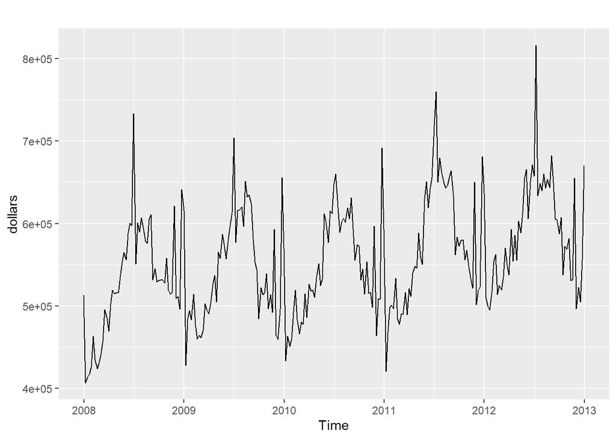

```r
dat = read.csv("C:/Users/shash/Documents/MScA/Courses/Spring 2021/Time Series/Project/beer_drug_groupby 2008-2012.csv")

dollars = ts(dat$DOLLARS, start=decimal_date(ymd("2007-12-31")), frequency = 52)
autoplot(dollars)
```

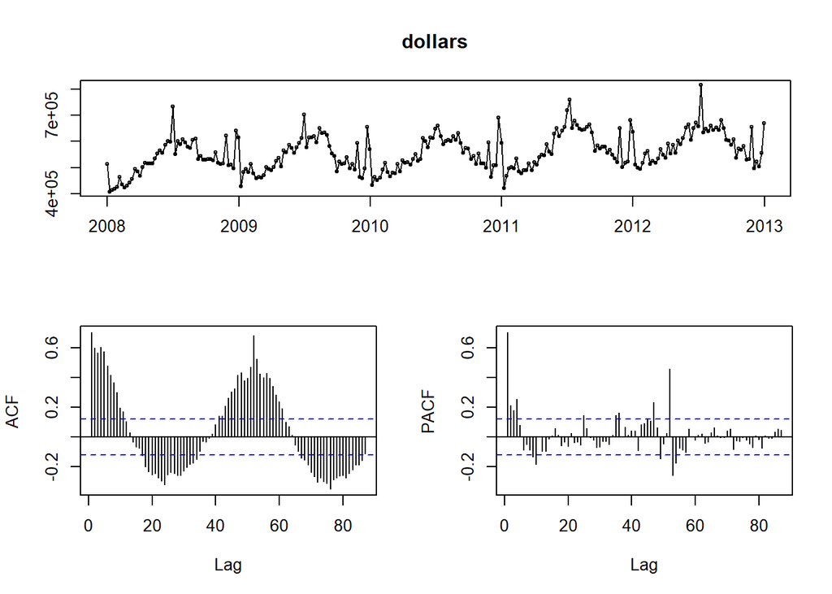

```r
tsdisplay(dollars)
```

There is a slight trend in the data as the beer sale is increasing with time. However it is not clear from the data would need Box Cox transformation. Let’s apply the Box cox transformation to check the lambda value.

```r
# lets find the value of lambda
lambda <- BoxCox.lambda(dollars)
lambda
```

```
## [1] 0.4264446
```

Split in train and test

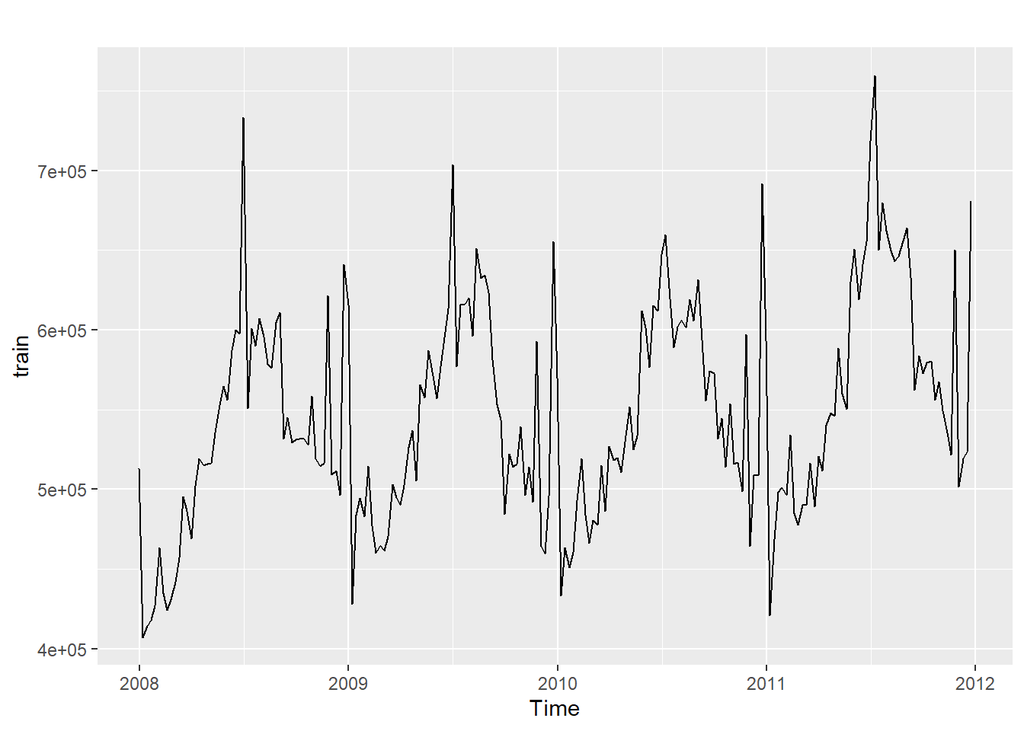

```r
train = window(dollars, start=decimal_date(ymd("2007-12-31")), end=decimal_date(ymd("2011-12-25")), frequency = 52)
test = window(dollars, start=decimal_date(ymd("2011-12-26")), end=decimal_date(ymd("2012-12-30")), frequency = 52)

autoplot(train)
```

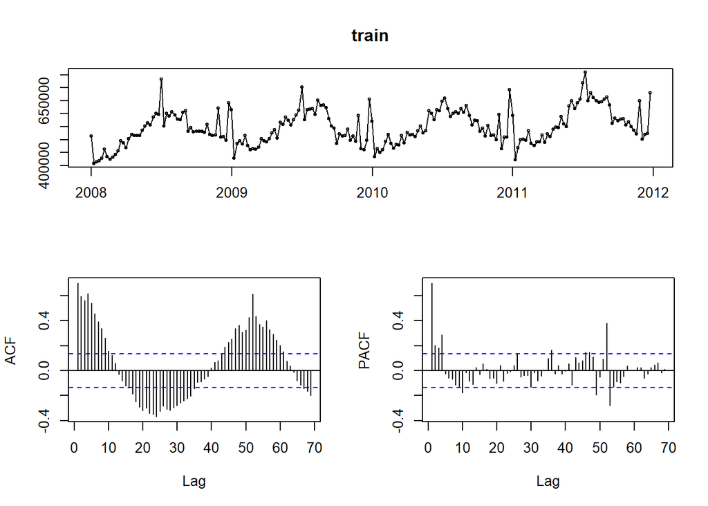

```r
tsdisplay(train)
```

Plot ACF and PACF plots

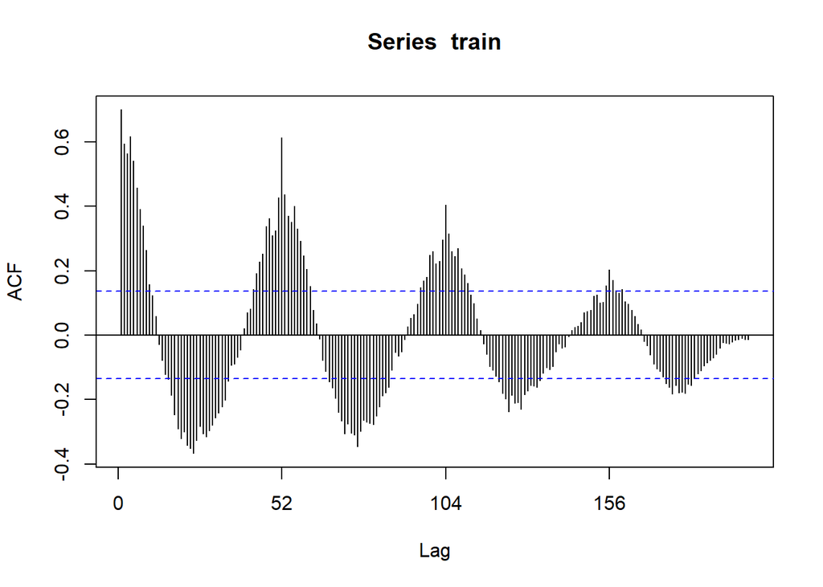

```r
Acf(train, 200)
```

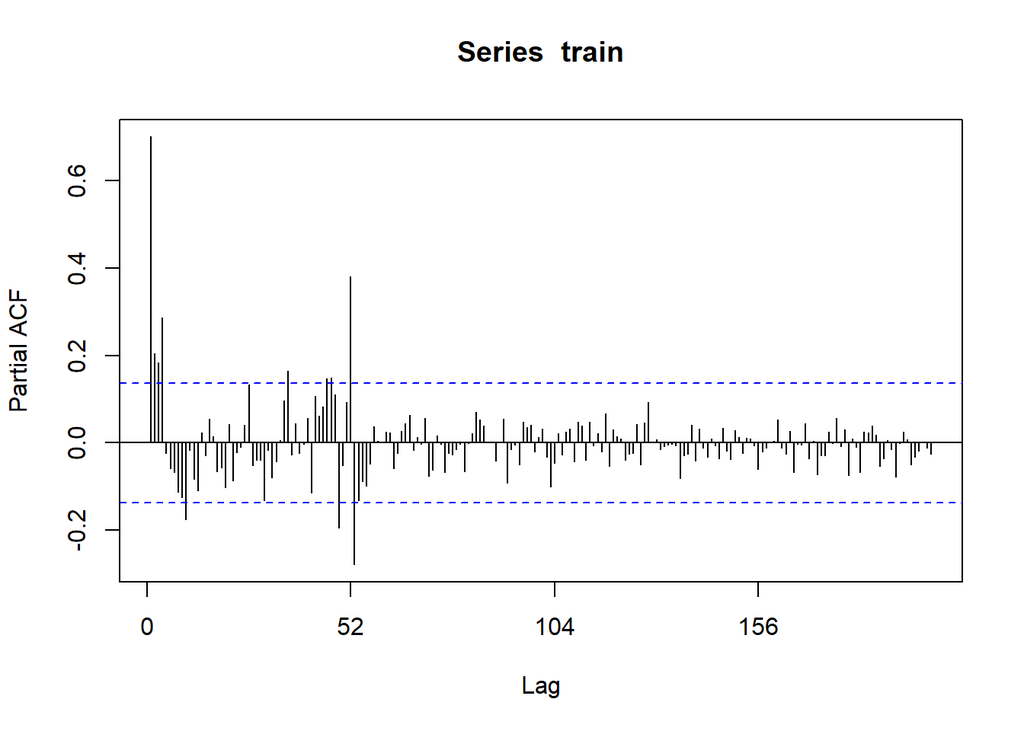

```r
Pacf(train, 200)
```

Based on the ACF and PACF plot, there is a trend and seasonality component to the data. Data appears to be model AR = 4 for trend and AR = 1 for seasonality.

Let’s run the kpss and adf test to check for stationarity.

```r
kpss.test(train)
```

```
##
##  KPSS Test for Level Stationarity
##
## data:  train
## KPSS Level = 0.61537, Truncation lag parameter = 4, p-value = 0.02124
```

```r
adf.test(train)
```

```
##
##  Augmented Dickey-Fuller Test
##
## data:  train
## Dickey-Fuller = -2.8879, Lag order = 5, p-value = 0.2039
## alternative hypothesis: stationary
```

As per both the KPSS test and ADF test, the data is not trend stationary.

Let’s try to apply differencing to see if we can remove seasonality.

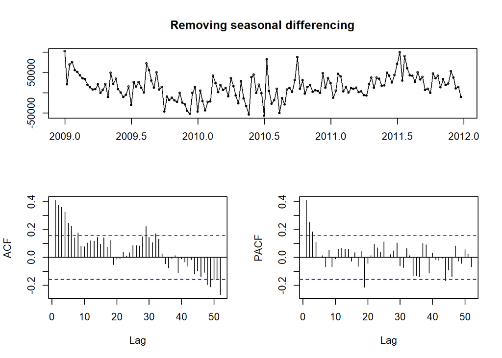

```r
tsdisplay(diff(train, 52), main = 'Removing seasonal differencing')
```

```r
adf.test(diff(train, 52))
```

```
##
##  Augmented Dickey-Fuller Test
##
## data:  diff(train, 52)
## Dickey-Fuller = -3.7694, Lag order = 5, p-value = 0.02235
## alternative hypothesis: stationary
```

```r
kpss.test(diff(train, 52))
```

```
##
##  KPSS Test for Level Stationarity
##
## data:  diff(train, 52)
## KPSS Level = 0.50919, Truncation lag parameter = 4, p-value = 0.0396
```

Here the KPSS Test is showing that the data is not stationary, however the ADF test is showing that differenced data is stationary. Let’s run the auto arima model to get the parameters.

Run auto arima

```r
mod1 = auto.arima(train, seasonal = TRUE)
summary(mod1)
```

```
## Series: train
## ARIMA(2,1,1)(0,1,1)[52]
##
## Coefficients:
##           ar1      ar2      ma1     sma1
##       -0.0519  -0.0256  -0.7122  -0.2797
## s.e.   0.1745   0.1412   0.1594   0.0964
##
## sigma^2 estimated as 652237185:  log likelihood=-1793.36
## AIC=3596.71   AICc=3597.12   BIC=3611.93
##
## Training set error measures:
##                     ME     RMSE      MAE        MPE     MAPE      MASE
## Training set -1350.721 21760.03 14341.86 -0.3735957 2.575591 0.5474757
##                    ACF1
## Training set 0.01932338
```

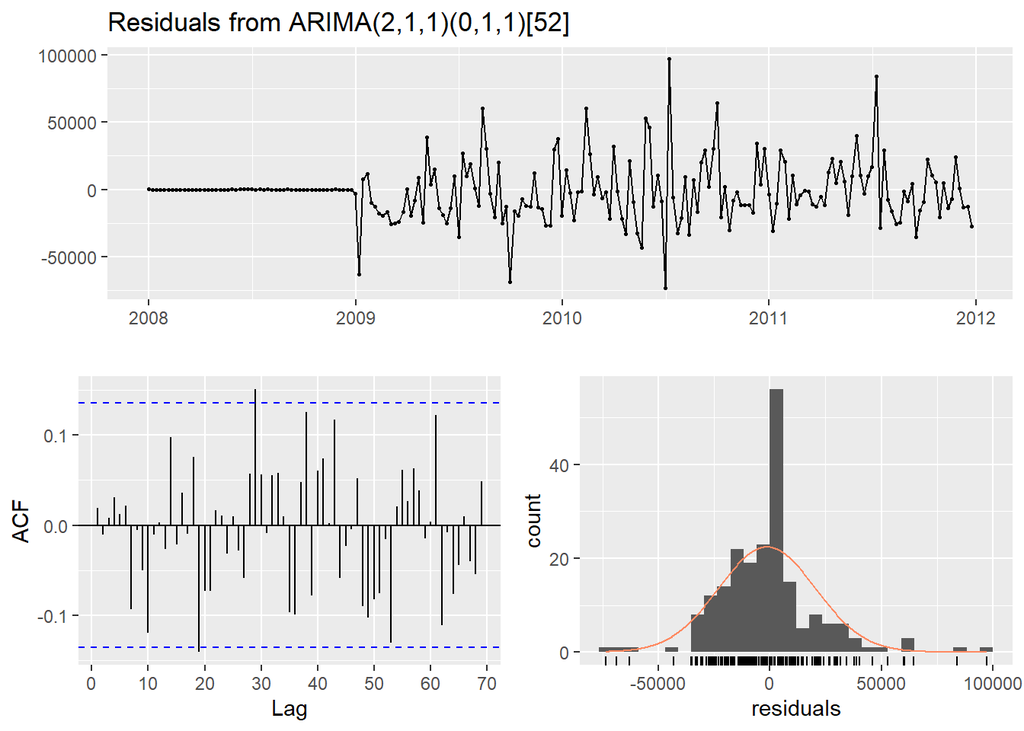

```
##
##  Ljung-Box test
##
## data:  Residuals from ARIMA(2,1,1)(0,1,1)[52]
## Q* = 40.86, df = 38, p-value = 0.346
##
## Model df: 4.   Total lags used: 42
```

```r
checkresiduals(mod1)
```

As per the check residuals the model is good fit (high p-value - accept null hypothesis that the model is good fit and the data are independently distributed). The residuals look normally distributed. The model looks good.

Forecast on auto arima model

```r
forecast_mod1 = forecast(mod1,h=53)
forecast_mod1
```

```
##          Point Forecast    Lo 80    Hi 80    Lo 95    Hi 95
## 2011.997       610211.5 577478.5 642944.5 560150.7 660272.3
## 2012.016       444874.1 411242.8 478505.4 393439.5 496308.7
## 2012.036       488260.3 453647.9 522872.8 435325.1 541195.5
## 2012.055       507778.9 472065.7 543492.1 453160.2 562397.5
## 2012.074       511525.6 474755.0 548296.2 455289.8 567761.3
## 2012.093       517138.0 479342.7 554933.3 459335.1 574940.9
## 2012.113       546678.7 507885.4 585472.1 487349.5 606008.0
## 2012.132       502893.4 463127.1 542659.8 442076.0 563710.9
## 2012.151       494644.7 453928.6 535360.9 432374.7 556914.8
## 2012.170       506574.5 464930.2 548218.8 442885.0 570264.0
## 2012.190       506919.6 464367.4 549471.8 441841.6 571997.6
## 2012.209       536055.6 492614.4 579496.7 469618.0 602493.1
## 2012.228       509932.2 465619.9 554244.4 442162.4 577701.9
## 2012.247       540318.7 495152.2 585485.3 471242.4 609395.0
## 2012.266       533349.3 487344.3 579354.3 462990.7 603707.9
## 2012.286       555783.2 508954.8 602611.7 484165.3 627401.2
## 2012.305       560298.0 512660.4 607935.7 487442.5 633153.5
## 2012.324       561509.0 513075.7 609942.4 487436.7 635581.4
## 2012.343       599401.3 550185.2 648617.5 524131.7 674670.9
## 2012.363       573319.8 523333.1 623306.5 496871.7 649767.9
## 2012.382       570262.4 519516.9 621008.0 492653.8 647871.1
## 2012.401       642893.1 591399.8 694386.4 564141.0 721645.3
## 2012.420       654488.1 602257.9 706718.4 574608.9 734367.4
## 2012.440       628587.5 575630.5 681544.4 547596.8 709578.2
## 2012.459       653356.8 599683.0 707030.7 571269.8 735443.9
## 2012.478       664294.1 609912.8 718675.4 581125.1 747463.1
## 2012.497       724647.1 669567.4 779726.7 640410.0 808884.1
## 2012.516       745955.1 690185.9 801724.4 660663.4 831246.8
## 2012.536       662139.4 605689.0 718589.8 575805.9 748472.9
## 2012.555       676960.8 619837.3 734084.3 589597.9 764323.6
## 2012.574       667571.0 609782.2 725359.7 579190.7 755951.2
## 2012.593       657699.4 599253.0 716145.7 568313.4 747085.4
## 2012.613       654708.9 595612.2 713805.6 564328.3 745089.5
## 2012.632       659575.8 599835.8 719315.8 568211.4 750940.2
## 2012.651       664535.9 604159.6 724912.3 572198.3 756873.6
## 2012.670       675232.5 614226.4 736238.6 581931.7 768533.3
## 2012.690       641152.5 579523.1 702782.0 546898.4 735406.6
## 2012.709       581013.4 518766.8 643259.9 485815.5 676211.2
## 2012.728       599312.5 536455.0 662170.1 503180.2 695444.9
## 2012.747       587774.7 524312.0 651237.4 490716.8 684832.5
## 2012.766       586412.5 522350.4 650474.7 488437.9 684387.1
## 2012.786       589391.6 524735.6 654047.7 490508.8 688274.5
## 2012.805       565818.2 500573.7 631062.7 466035.4 665601.0
## 2012.824       583929.6 518101.9 649757.3 483254.8 684604.4
## 2012.843       559917.1 493511.3 626322.8 458358.2 661475.9
## 2012.863       551067.0 484088.1 618045.9 448631.7 653502.3
## 2012.882       536055.4 468508.3 603602.5 432751.0 639359.8
## 2012.901       656645.9 588535.3 724756.5 552479.8 760812.1
## 2012.920       512951.5 444282.0 581621.0 407930.6 617972.4
## 2012.940       534449.1 465225.3 603672.9 428580.4 640317.8
## 2012.959       539311.4 469537.6 609085.1 432601.6 646021.2
## 2012.978       701950.4 631631.0 772269.9 594406.2 809494.7
## 2012.997       625394.7 548001.0 702788.3 507031.3 743758.0
```

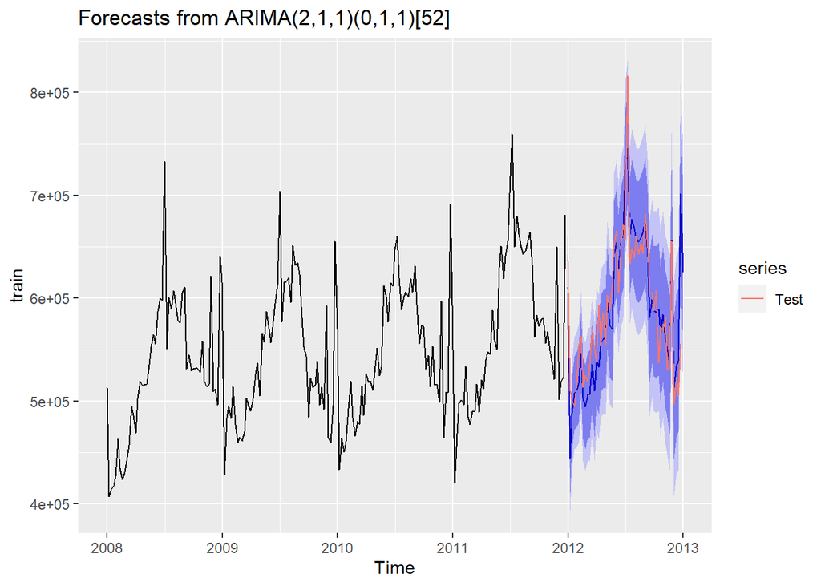

```r
autoplot(forecast_mod1) + autolayer(test, series = "Test")
```

Let’s calculate the accuracy based on the auto arima model

```r
accuracy(forecast_mod1, test)
```

```
##                     ME     RMSE      MAE        MPE     MAPE      MASE
## Training set -1350.721 21760.03 14341.86 -0.3735957 2.575591 0.5474757
## Test set      2367.179 33781.47 23150.88  0.3640999 3.970243 0.8837447
##                    ACF1 Theil's U
## Training set 0.01932338        NA
## Test set     0.08265698 0.6961225
```

Different Arima model

```r
mod2 = Arima(train,order=c(4,1,1), seasonal = list(order=c(1,1,0)))
summary(mod2)
```

```
## Series: train
## ARIMA(4,1,1)(1,1,0)[52]
##
## Coefficients:
##          ar1     ar2     ar3     ar4      ma1     sar1
##       0.1647  0.1316  0.1349  0.1029  -0.9333  -0.2636
## s.e.  0.1089  0.1007  0.0952  0.0909   0.0704   0.0857
##
## sigma^2 estimated as 651913999:  log likelihood=-1792.18
## AIC=3598.36   AICc=3599.12   BIC=3619.67
##
## Training set error measures:
##                     ME     RMSE      MAE        MPE     MAPE     MASE
## Training set -1549.911 21610.09 14209.06 -0.4160479 2.554413 0.542406
##                    ACF1
## Training set 0.01550368
```

Forecast on new arima model

```r
forecast_mod2 = forecast(mod2,h=53)
forecast_mod2
```

```
##          Point Forecast    Lo 80    Hi 80    Lo 95    Hi 95
## 2011.997       608463.7 575742.3 641185.0 558420.7 658506.6
## 2012.016       444560.9 410975.0 478146.8 393195.7 495926.2
## 2012.036       487384.7 452919.5 521849.8 434674.7 540094.6
## 2012.055       506767.6 471180.6 542354.5 452342.1 561193.1
## 2012.074       513934.1 477214.7 550653.5 457776.6 570091.5
## 2012.093       519302.6 481983.9 556621.3 462228.6 576376.6
## 2012.113       554226.5 516352.6 592100.4 496303.3 612149.6
## 2012.132       509208.9 470821.9 547595.9 450501.0 567916.7
## 2012.151       499755.3 460918.7 538591.8 440359.9 559150.6
## 2012.170       512962.6 473734.0 552191.2 452967.7 572957.6
## 2012.190       512545.2 472949.8 552140.6 451989.3 573101.1
## 2012.209       541936.5 501996.7 581876.2 480853.9 603019.1
## 2012.228       514378.6 474114.1 554643.2 452799.4 575957.9
## 2012.247       548485.7 507911.2 589060.1 486432.4 610539.0
## 2012.266       539563.7 498690.0 580437.5 477052.8 602074.7
## 2012.286       560871.3 519707.3 602035.4 497916.3 623826.3
## 2012.305       564473.0 523025.9 605920.1 501085.1 627860.9
## 2012.324       568921.6 527197.4 610645.9 505109.9 632733.4
## 2012.343       605166.6 563170.0 647163.2 540938.3 669394.9
## 2012.363       577062.7 534797.8 619327.5 512424.1 641701.2
## 2012.382       572342.2 529812.6 614871.9 507298.8 637385.7
## 2012.401       651645.7 608854.3 694437.1 586201.9 717089.5
## 2012.420       664096.8 621046.3 707147.3 598256.7 729936.9
## 2012.440       634362.0 591054.7 677669.2 568129.2 700594.7
## 2012.459       660574.0 617012.2 704135.9 593951.9 727196.1
## 2012.478       670547.5 626733.0 714362.0 603539.0 737556.0
## 2012.497       726132.5 682067.2 770197.8 658740.4 793524.5
## 2012.516       759864.0 715549.6 804178.3 692091.0 827637.0
## 2012.536       668579.3 624017.4 713141.1 600427.8 736730.8
## 2012.555       682179.9 637372.1 726987.7 613652.3 750707.6
## 2012.574       672738.2 627685.9 717790.5 603836.7 741639.7
## 2012.593       664550.9 619255.6 709846.2 595277.7 733824.1
## 2012.613       658298.6 612761.6 703835.5 588655.8 727941.4
## 2012.632       665460.9 619683.6 711238.2 595450.5 735471.2
## 2012.651       669061.9 623045.6 715078.2 598686.0 739437.8
## 2012.670       681978.2 635724.2 728232.3 611238.7 752717.7
## 2012.690       649090.7 602600.1 695581.2 577989.5 720191.9
## 2012.709       586828.3 540102.4 633554.2 515367.2 658289.3
## 2012.728       607486.3 560526.3 654446.2 535667.2 679305.3
## 2012.747       599052.5 551859.6 646245.4 526877.2 671227.8
## 2012.766       593068.1 545643.5 640492.8 520538.4 665597.9
## 2012.786       597354.8 549699.5 645010.1 524472.4 670237.3
## 2012.805       571462.3 523577.5 619347.1 498228.8 644695.7
## 2012.824       590248.3 542135.1 638361.5 516665.5 663831.0
## 2012.843       566850.6 518510.1 615191.1 492920.2 640781.1
## 2012.863       556936.4 508369.6 605503.2 482659.9 631212.9
## 2012.882       541779.6 492987.6 590571.6 467158.7 616400.6
## 2012.901       662609.3 613593.2 711625.5 587645.6 737573.1
## 2012.920       517982.5 468743.2 567221.8 442677.5 593287.6
## 2012.940       542729.1 493267.6 592190.6 467084.3 618373.9
## 2012.959       545869.6 496187.0 595552.2 469886.6 621852.6
## 2012.978       710241.6 660338.8 760144.4 633921.8 786561.3
## 2012.997       630823.8 573217.9 688429.7 542723.1 718924.5
```

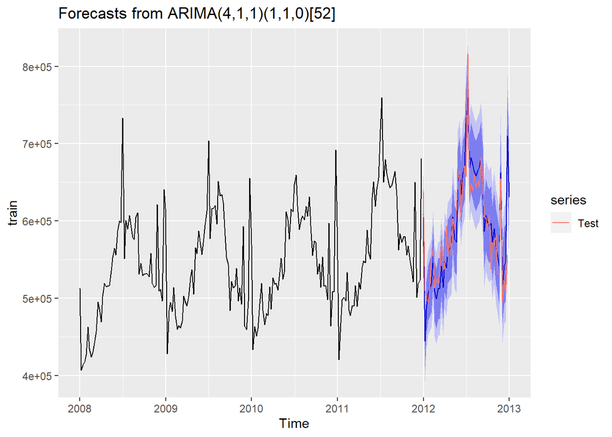

```r
autoplot(forecast_mod2) + autolayer(test, series = "Test")
```

Accuracy

```r
accuracy(forecast_mod2, test)
```

```
##                     ME     RMSE      MAE        MPE     MAPE      MASE
## Training set -1549.911 21610.09 14209.06 -0.4160479 2.554413 0.5424060
## Test set     -3295.261 34226.49 23104.82 -0.5895494 3.985681 0.8819862
##                    ACF1 Theil's U
## Training set 0.01550368        NA
## Test set     0.12136744 0.7065309
```

Let’s Run EACF

```r
eacf(train)
```

```
## AR/MA
##   0 1 2 3 4 5 6 7 8 9 10 11 12 13
## 0 x x x x x x x x x x o  o  o  o
## 1 x o o x o o o o o o o  o  o  o
## 2 x o o x o o o o o o o  o  o  o
## 3 x x x x o o o o o o o  o  o  o
## 4 o x x x o o o o o o o  o  o  o
## 5 o o o o o o o o o o o  o  o  o
## 6 x x o o o x o o o o o  o  o  o
## 7 x x x o o x o o o o o  o  o  o
```

Trying new models

```r
mod3 = Arima(train,order=c(1,1,0), seasonal = list(order=c(1,1,1)))
summary(mod3)
```

```
## Series: train
## ARIMA(1,1,0)(1,1,1)[52]
##
## Coefficients:
##           ar1     sar1    sma1
##       -0.4670  -0.8008  0.6221
## s.e.   0.0756   0.7878  0.9481
##
## sigma^2 estimated as 762221816:  log likelihood=-1806.88
## AIC=3621.75   AICc=3622.02   BIC=3633.93
##
## Training set error measures:
##                     ME     RMSE     MAE        MPE     MAPE      MASE
## Training set -691.2218 23601.02 14862.2 -0.2167762 2.652585 0.5673387
##                    ACF1
## Training set -0.1276444
```

```r
print("=================")
```

```
## [1] "================="
```

```r
mod4 = Arima(train,order=c(3,1,1), seasonal = list(order=c(1,1,0)))
summary(mod4)
```

```
## Series: train
## ARIMA(3,1,1)(1,1,0)[52]
##
## Coefficients:
```

```
##           ar1      ar2      ar3      ma1     sar1
##       -0.1115  -0.0768  -0.0208  -0.6452  -0.2709
## s.e.   0.0031      NaN   0.0077      NaN      NaN
##
## sigma^2 estimated as 656779953:  log likelihood=-1793.06
## AIC=3598.12   AICc=3598.69   BIC=3616.38
##
## Training set error measures:
##                     ME     RMSE      MAE        MPE     MAPE      MASE
## Training set -1214.951 21763.26 14386.67 -0.3443662 2.580126 0.5491861
##                    ACF1
## Training set 0.02092282
```

```r
print("=================")
```

```
## [1] "================="
```

```r
mod5 = Arima(train,order=c(1,1,2), seasonal = list(order=c(0,1,1)))
summary(mod5)
```

```
## Series: train
## ARIMA(1,1,2)(0,1,1)[52]
##
## Coefficients:
```

```
##           ar1      ma1      ma2     sma1
##       -0.4575  -0.3007  -0.3324  -0.2779
## s.e.      NaN      NaN      NaN   0.0957
##
## sigma^2 estimated as 652699072:  log likelihood=-1793.39
## AIC=3596.78   AICc=3597.19   BIC=3612
##
## Training set error measures:
##                     ME     RMSE      MAE        MPE    MAPE      MASE      ACF1
## Training set -1390.726 21767.74 14312.78 -0.3818162 2.57141 0.5463656 0.0132972
```

```r
print("=================")
```

```
## [1] "================="
```

```r
mod6 = Arima(train,order=c(2,1,2), seasonal = list(order=c(0,1,1)))
summary(mod6)
```

```
## Series: train
## ARIMA(2,1,2)(0,1,1)[52]
##
## Coefficients:
##           ar1      ar2      ma1      ma2     sma1
##       -0.3029  -0.0356  -0.4613  -0.1836  -0.2798
## s.e.   1.5698   0.1296   1.5667   1.1726   0.0965
##
## sigma^2 estimated as 656493389:  log likelihood=-1793.35
## AIC=3598.7   AICc=3599.26   BIC=3616.96
##
## Training set error measures:
##                     ME     RMSE      MAE        MPE     MAPE      MASE
## Training set -1355.392 21758.51 14334.91 -0.3745987 2.574206 0.5472103
##                    ACF1
## Training set 0.01913285
```

```r
print("=================")
```

```
## [1] "================="
```

```r
mod7 = Arima(train,order=c(1,1,4), seasonal = list(order=c(0,1,1)))
summary(mod7)
```

```
## Series: train
## ARIMA(1,1,4)(0,1,1)[52]
##
## Coefficients:
##          ar1      ma1     ma2     ma3      ma4     sma1
##       0.8066  -1.5963  0.6487  0.0579  -0.0858  -0.2799
## s.e.  0.1963   0.2101  0.2184  0.1547   0.0896   0.0979
##
## sigma^2 estimated as 648717707:  log likelihood=-1792.1
## AIC=3598.19   AICc=3598.95   BIC=3619.5
##
## Training set error measures:
##                     ME     RMSE      MAE      MPE     MAPE      MASE       ACF1
## Training set -1664.154 21557.05 14170.35 -0.43878 2.548428 0.5409284 0.02373364
```

```r
print("=================")
```

```
## [1] "================="
```

```r
mod8 = Arima(train,order=c(2,1,4), seasonal = list(order=c(0,1,1)))
summary(mod8)
```

```
## Series: train
## ARIMA(2,1,4)(0,1,1)[52]
##
## Coefficients:
```

```
##           ar1      ar2      ma1      ma2      ma3     ma4     sma1
##       -0.5699  -0.3214  -0.1945  -0.1041  -0.2096  0.0001  -0.2801
## s.e.      NaN      NaN      NaN   0.7994      NaN  0.0894   0.0966
##
## sigma^2 estimated as 665073202:  log likelihood=-1793.32
## AIC=3602.65   AICc=3603.63   BIC=3626.99
##
## Training set error measures:
##                     ME     RMSE     MAE        MPE    MAPE      MASE       ACF1
## Training set -1368.977 21753.74 14311.7 -0.3775053 2.56992 0.5463242 0.01915463
```

```r
print("=================")
```

```
## [1] "================="
```

```r
mod9 = Arima(train,order=c(4,1,0), seasonal = list(order=c(1,1,0)))
summary(mod9)
```

```
## Series: train
## ARIMA(4,1,0)(1,1,0)[52]
##
## Coefficients:
##           ar1      ar2      ar3      ar4     sar1
##       -0.7355  -0.5198  -0.3051  -0.1293  -0.2721
## s.e.   0.0820   0.0984   0.0982   0.0823   0.0853
##
## sigma^2 estimated as 6.64e+08:  log likelihood=-1794.05
## AIC=3600.11   AICc=3600.68   BIC=3618.37
##
## Training set error measures:
##                     ME     RMSE      MAE        MPE     MAPE      MASE
## Training set -1061.243 21882.74 14462.93 -0.3107466 2.592788 0.5520971
##                     ACF1
## Training set 0.004830234
```

```r
print("=================")
```

```
## [1] "================="
```

```r
mod10 = Arima(train,order=c(4,1,4), seasonal = list(order=c(0,1,1)))
summary(mod10)
```

```
## Series: train
## ARIMA(4,1,4)(0,1,1)[52]
##
## Coefficients:
```

```
##          ar1     ar2     ar3    ar4      ma1     ma2     ma3    ma4     sma1
##       -0.272  0.7121  0.1885  0.128  -0.5156  -0.927  0.4147  0.028  -0.2650
## s.e.     NaN  0.1804     NaN  0.115      NaN     NaN     NaN    NaN   0.0983
##
## sigma^2 estimated as 651440758:  log likelihood=-1791.68
## AIC=3603.36   AICc=3604.89   BIC=3633.79
##
## Training set error measures:
##                     ME     RMSE      MAE        MPE     MAPE      MASE
## Training set -2024.253 21383.67 14270.76 -0.5045812 2.571225 0.5447613
##                   ACF1
## Training set 0.0159836
```

NEW Arima model –> mod5 since this is the best performing, although not as good as the auto arima Forecast on new arima model

```r
forecast_mod5 = forecast(mod5,h=53)
forecast_mod5
```

```
##          Point Forecast    Lo 80    Hi 80    Lo 95    Hi 95
## 2011.997       610150.5 577406.1 642894.9 560072.3 660228.7
## 2012.016       445037.2 411349.2 478725.1 393515.9 496558.5
## 2012.036       489097.6 454380.6 523814.6 436002.6 542192.6
## 2012.055       508560.3 472894.1 544226.5 454013.6 563107.0
## 2012.074       512330.7 475717.7 548943.7 456335.9 568325.5
## 2012.093       517861.0 480335.0 555387.0 460469.9 575252.0
## 2012.113       547490.0 509068.2 585911.7 488728.9 606251.0
## 2012.132       503655.3 464360.1 542950.4 443558.6 563751.9
## 2012.151       495404.0 455253.6 535554.3 433999.3 556808.6
## 2012.170       507342.2 466354.9 548329.6 444657.5 570027.0
## 2012.190       507678.9 465871.1 549486.7 443739.4 571618.4
## 2012.209       536797.6 494185.2 579409.9 471627.6 601967.5
## 2012.228       510656.3 467254.3 554058.3 444278.7 577034.0
## 2012.247       541076.4 496898.8 585253.9 473512.6 608640.1
## 2012.266       534077.3 489137.6 579017.1 465347.9 602806.7
## 2012.286       556540.5 510851.3 602229.7 486664.9 626416.1
## 2012.305       561072.4 514645.9 607499.0 490069.1 632075.7
## 2012.324       562280.2 515127.8 609432.6 490166.8 634393.5
## 2012.343       600197.6 552330.3 648064.8 526991.0 673404.2
## 2012.363       574083.1 525511.6 622654.7 499799.4 648366.9
## 2012.382       570976.4 521710.6 620242.2 495630.9 646321.9
## 2012.401       643691.7 593741.3 693642.1 567299.2 720084.2
## 2012.420       655347.7 604722.0 705973.4 577922.3 732773.0
## 2012.440       629384.9 578092.8 680677.1 550940.4 707829.5
## 2012.459       654146.6 602196.5 706096.6 574695.8 733597.3
## 2012.478       665102.5 612502.7 717702.2 584658.1 745546.8
## 2012.497       725433.7 672192.3 778675.2 644008.0 806859.5
## 2012.516       746955.7 693080.1 800831.2 664560.1 829351.2
## 2012.536       662928.5 608426.2 717430.8 579574.4 746282.5
## 2012.555       677833.5 622711.6 732955.4 593531.8 762135.1
## 2012.574       668392.1 612657.5 724126.7 583153.4 753630.8
## 2012.593       658512.8 602172.2 714853.5 572347.3 744678.4
## 2012.613       655485.9 598545.6 712426.1 568403.3 742568.4
## 2012.632       660356.9 602823.4 717890.5 572366.9 748346.9
## 2012.651       665333.7 607212.9 723454.6 576445.5 754221.9
## 2012.670       676029.3 617327.0 734731.6 586251.9 765806.7
## 2012.690       641979.8 582701.8 701257.8 551322.0 732637.7
## 2012.709       581754.9 521906.7 641603.1 490225.0 673284.8
## 2012.728       600089.8 539676.9 660502.8 507696.2 692483.5
## 2012.747       588570.2 527597.7 649542.7 495320.8 681819.6
## 2012.766       587229.9 525702.9 648756.9 493132.5 681327.4
## 2012.786       590205.3 528128.8 652281.8 495267.4 685143.1
## 2012.805       566612.9 503991.6 629234.1 470842.0 662383.8
## 2012.824       584686.4 521525.2 647847.6 488089.6 681283.1
## 2012.843       560713.4 497016.7 624410.0 463297.7 658129.0
## 2012.863       551828.0 487600.4 616055.6 453600.4 650055.7
## 2012.882       536818.6 472064.3 601572.8 437785.5 635851.6
## 2012.901       657460.8 592184.3 722737.4 557628.9 757292.7
## 2012.920       513726.7 447931.9 579521.5 413102.2 614351.1
## 2012.940       535223.1 468914.2 601532.1 433812.3 636633.9
## 2012.959       540068.8 473249.6 606887.9 437877.7 642259.8
## 2012.978       702695.1 635369.6 770020.6 599729.6 805660.5
## 2012.997       626109.4 551612.1 700606.7 512175.6 740043.2
```

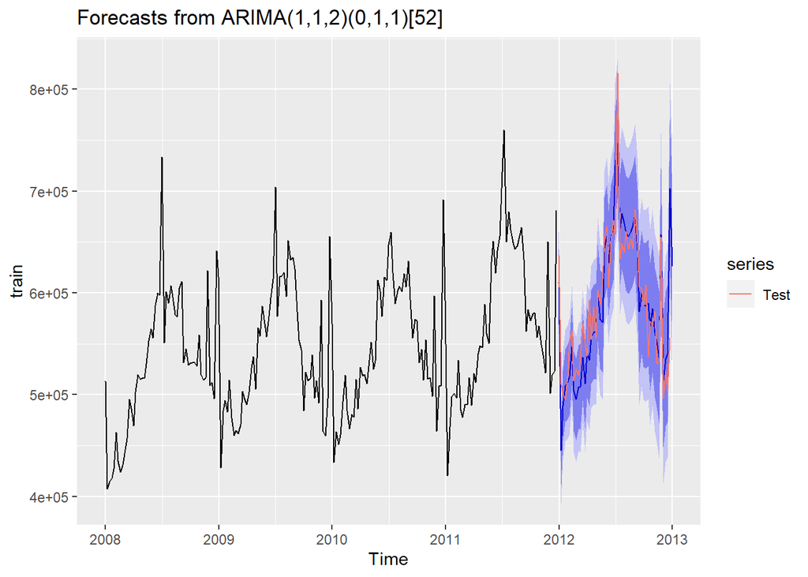

```r
autoplot(forecast_mod5) + autolayer(test, series = "Test")
```

Accuracy

```r
accuracy(forecast_mod5, test)
```

```
##                     ME     RMSE      MAE        MPE     MAPE      MASE
## Training set -1390.726 21767.74 14312.78 -0.3818162 2.571410 0.5463656
## Test set      1608.775 33768.34 23086.19  0.2345245 3.960578 0.8812750
##                    ACF1 Theil's U
## Training set 0.01329720        NA
## Test set     0.08438085 0.6956886
```

This model is giving worse train RMSE but better Test RMSE. This model is a better fit.

## Regression

Let’s create time series objects for Units, D and PR

```r
units_ts = ts(dat$UNITS, start=decimal_date(ymd("2007-12-31")), frequency = 52)
D_ts = ts(dat$D, start=decimal_date(ymd("2007-12-31")), frequency = 52)
PR_ts = ts(dat$PR, start=decimal_date(ymd("2007-12-31")), frequency = 52)

#Split the data into train and test for units, D and PR
train_units = window(units_ts, start=decimal_date(ymd("2007-12-31")), end=decimal_date(ymd("2011-12-25")), frequency = 52)
test_units = window(units_ts, start=decimal_date(ymd("2011-12-26")), end=decimal_date(ymd("2012-12-30")), frequency = 52)
train_D = window(D_ts, start=decimal_date(ymd("2007-12-31")), end=decimal_date(ymd("2011-12-25")), frequency = 52)
test_D = window(D_ts, start=decimal_date(ymd("2011-12-26")), end=decimal_date(ymd("2012-12-30")), frequency = 52)
train_PR = window(PR_ts, start=decimal_date(ymd("2007-12-31")), end=decimal_date(ymd("2011-12-25")), frequency = 52)
test_PR = window(PR_ts, start=decimal_date(ymd("2011-12-26")), end=decimal_date(ymd("2012-12-30")), frequency = 52)
```

Let’s run a simple regression model

```r
mod_tslm = tslm(train ~ train_units+train_D+train_PR)
summary(mod_tslm)
```

```
##
## Call:
## tslm(formula = train ~ train_units + train_D + train_PR)
##
## Residuals:
##    Min     1Q Median     3Q    Max
## -50204  -9324    540   8525  60141
##
## Coefficients:
##               Estimate Std. Error t value Pr(>|t|)
## (Intercept) -1.194e+05  1.124e+04 -10.625  < 2e-16 ***
## train_units  7.347e+00  2.325e-01  31.596  < 2e-16 ***
## train_D      8.440e+01  6.850e+00  12.321  < 2e-16 ***
## train_PR     2.292e+01  4.125e+00   5.556 8.55e-08 ***
## ---
## Signif. codes:  0 '***' 0.001 '**' 0.01 '*' 0.05 '.' 0.1 ' ' 1
##
## Residual standard error: 15600 on 204 degrees of freedom
## Multiple R-squared:  0.9475, Adjusted R-squared:  0.9467
## F-statistic:  1227 on 3 and 204 DF,  p-value: < 2.2e-16
```

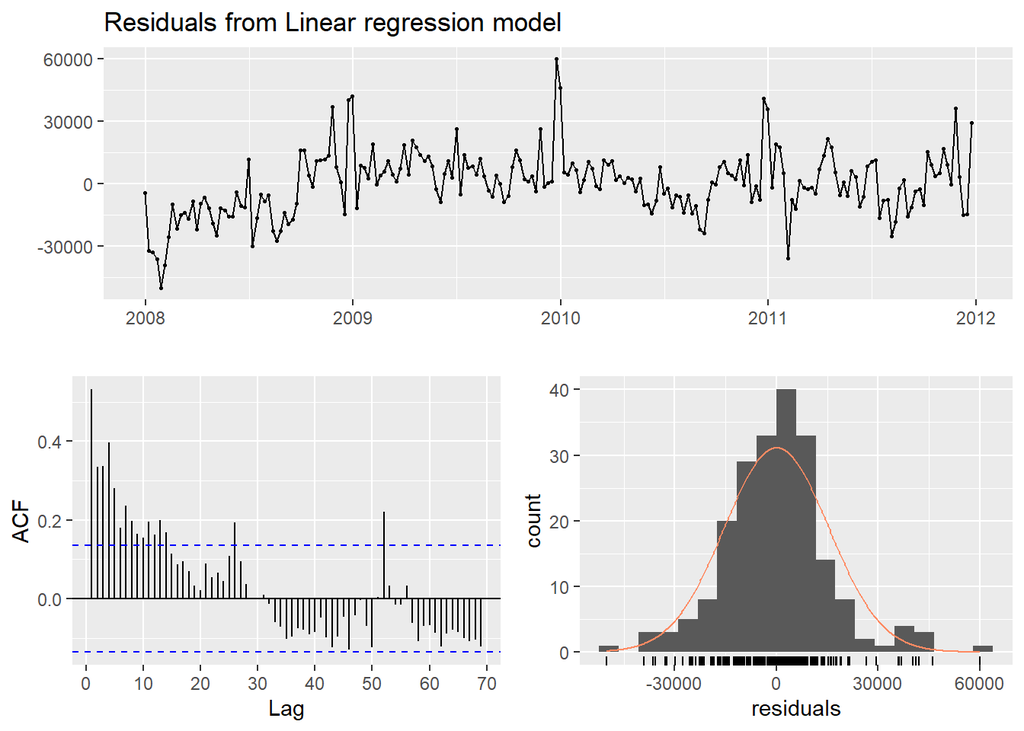

```
##
##  Breusch-Godfrey test for serial correlation of order up to 42
##
## data:  Residuals from Linear regression model
## LM test = 102.23, df = 42, p-value = 6.211e-07
```

```r
checkresiduals(mod_tslm)
```

## Regression with ARMA Errors

We will consider the following variables for regression:  
* Units  
* D (Stands for Display)  
* PR (Stands for Price Reduction)

Let’s plot each variable against the dollar amount

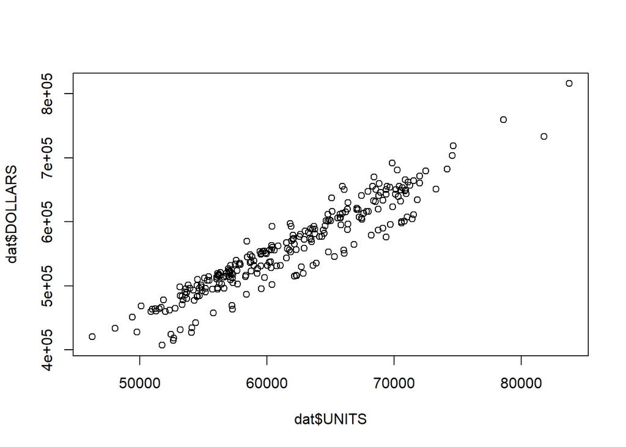

```r
plot(dat$UNITS, dat$DOLLARS)
```

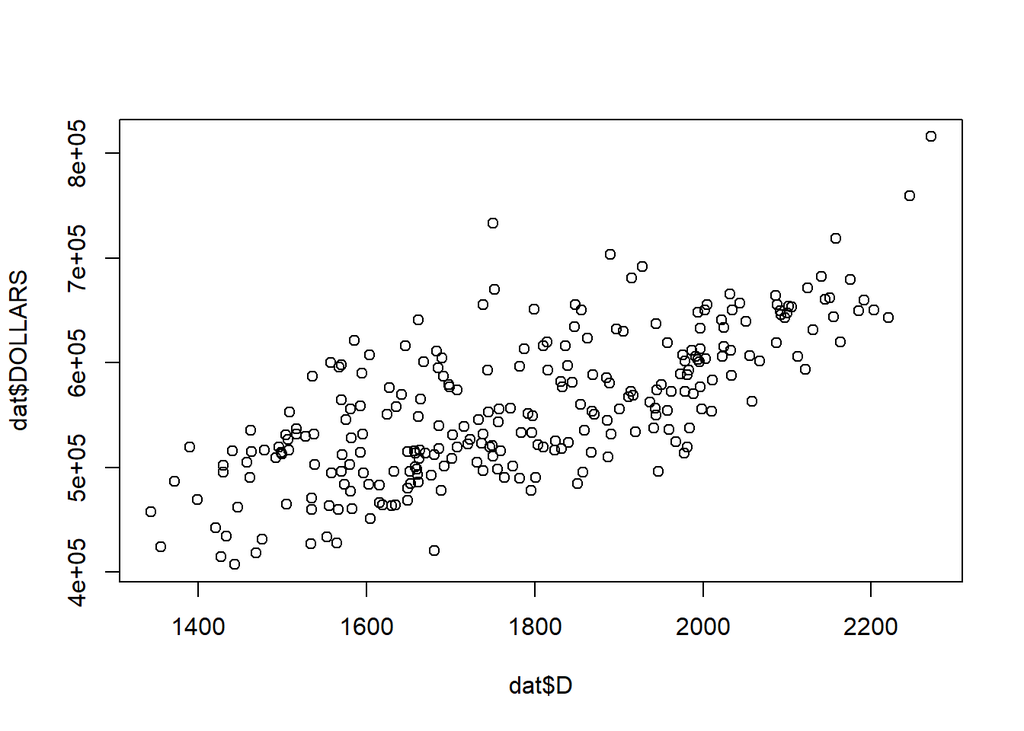

```r
plot(dat$D, dat$DOLLARS)
```

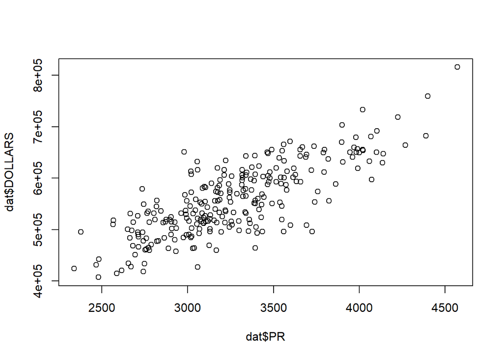

```r
plot(dat$PR, dat$DOLLARS)
```

Let’s calculate the correlation between Dollars and all three independent variables

```r
cor(dat$UNITS, dat$DOLLARS)
```

```
## [1] 0.9427643
```

```r
cor(dat$D, dat$DOLLARS)
```

```
## [1] 0.7121504
```

```r
cor(dat$PR, dat$DOLLARS)
```

```
## [1] 0.7861812
```

As can be seen that there is strong correlation between dollars and units but not very strong correlation between dollar and D and PR. Let’s apply log transformation to check if that improves the correlation.

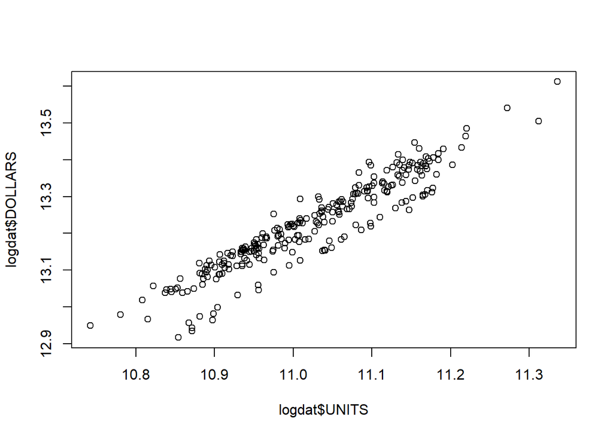

```r
logdat = log(dat)
plot(logdat$UNITS, logdat$DOLLARS)
```

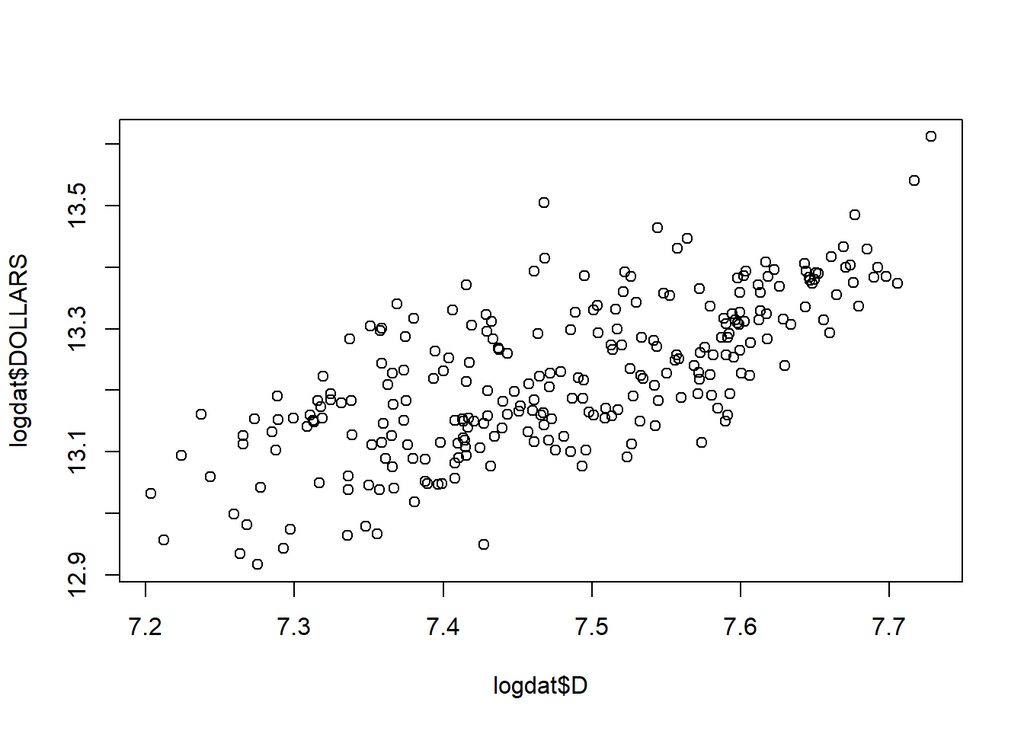

```r
plot(logdat$D, logdat$DOLLARS)
```

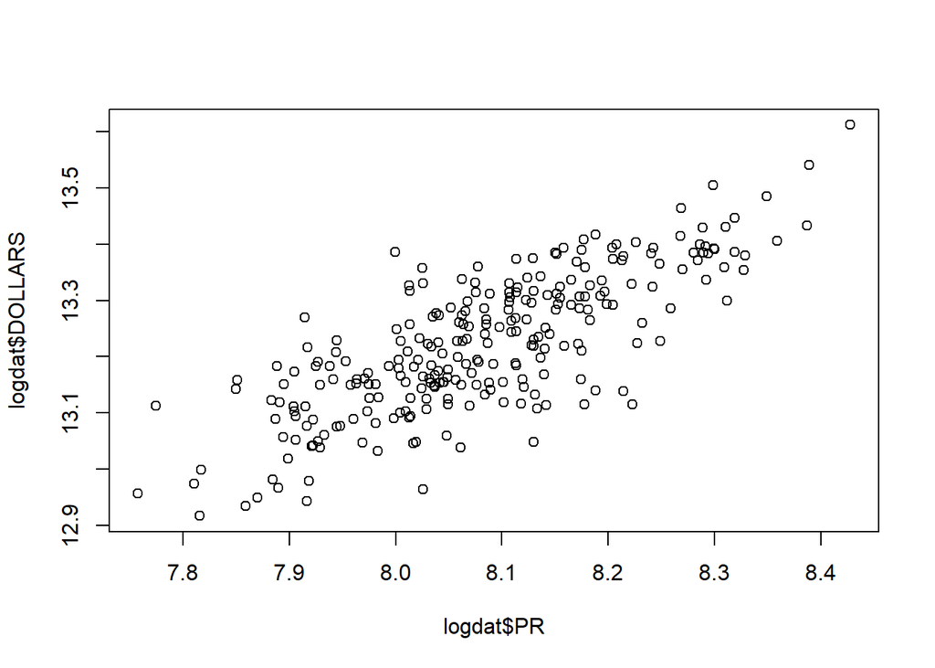

```r
plot(logdat$PR, logdat$DOLLARS)
```

```r
cor(logdat$UNITS, logdat$DOLLARS)
```

```
## [1] 0.9403626
```

```r
cor(logdat$D, logdat$DOLLARS)
```

```
## [1] 0.7083689
```

```r
cor(logdat$PR, logdat$DOLLARS)
```

```
## [1] 0.7780777
```

Log transformation is giving worse results. Let’s try square transformation

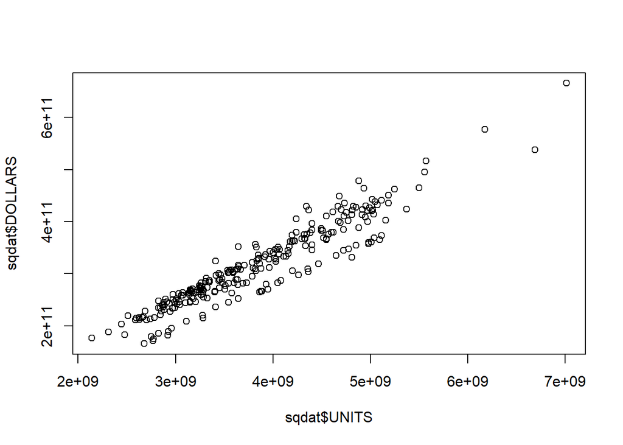

```r
sqdat = dat**2
plot(sqdat$UNITS, sqdat$DOLLARS)
```

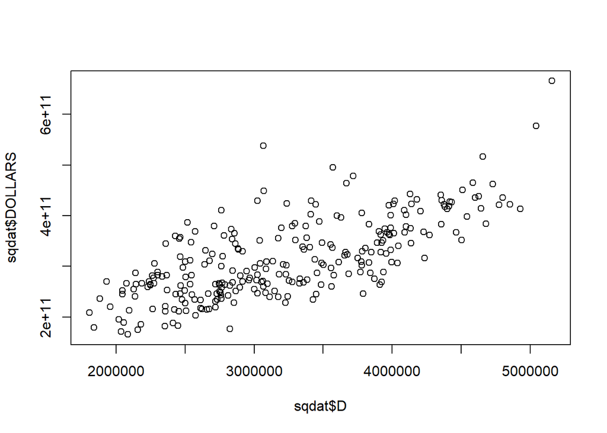

```r
plot(sqdat$D, sqdat$DOLLARS)
```

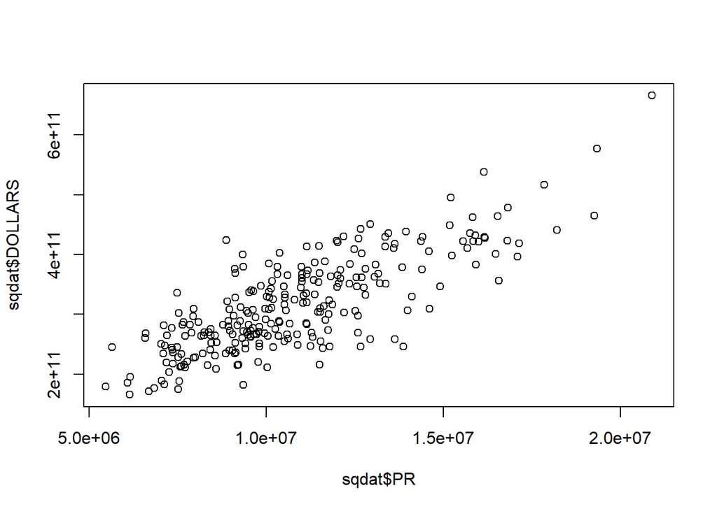

```r
plot(sqdat$PR, sqdat$DOLLARS)
```

```r
cor(sqdat$UNITS, sqdat$DOLLARS)
```

```
## [1] 0.9432759
```

```r
cor(sqdat$D, sqdat$DOLLARS)
```

```
## [1] 0.7131667
```

```r
cor(sqdat$PR, sqdat$DOLLARS)
```

```
## [1] 0.7936328
```

After looking at the plots and correlation coefficients, there doesn’t seem to be a lot of improvement in the correlation. Hence we do not want to use any transformation.

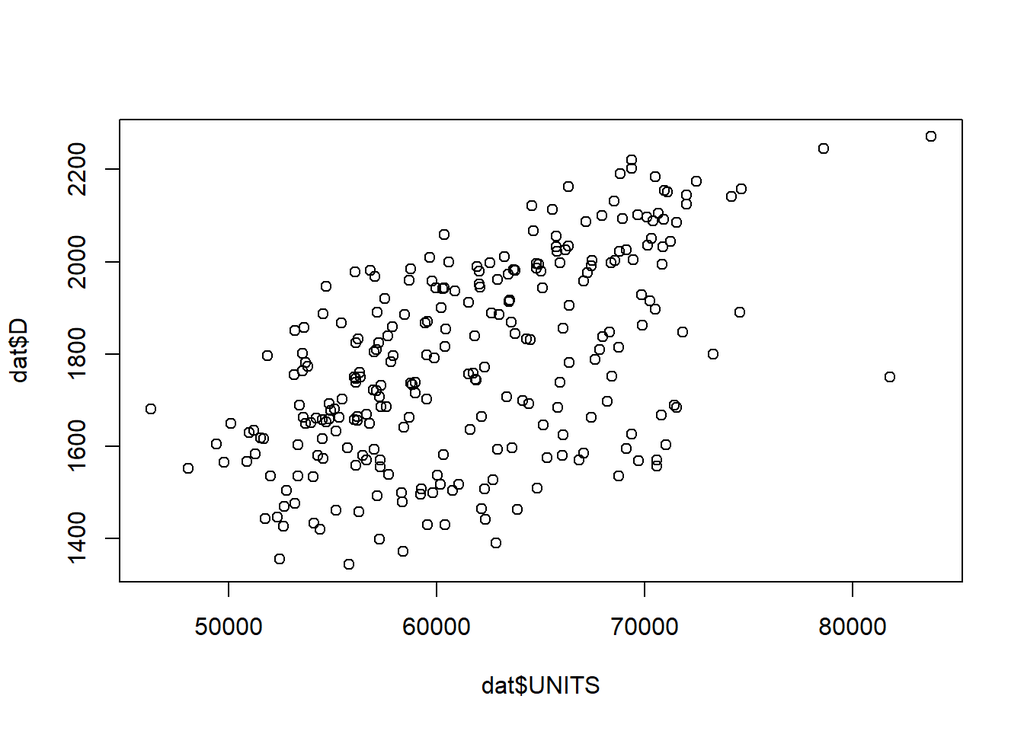

```r
plot(dat$UNITS, dat$D)
```

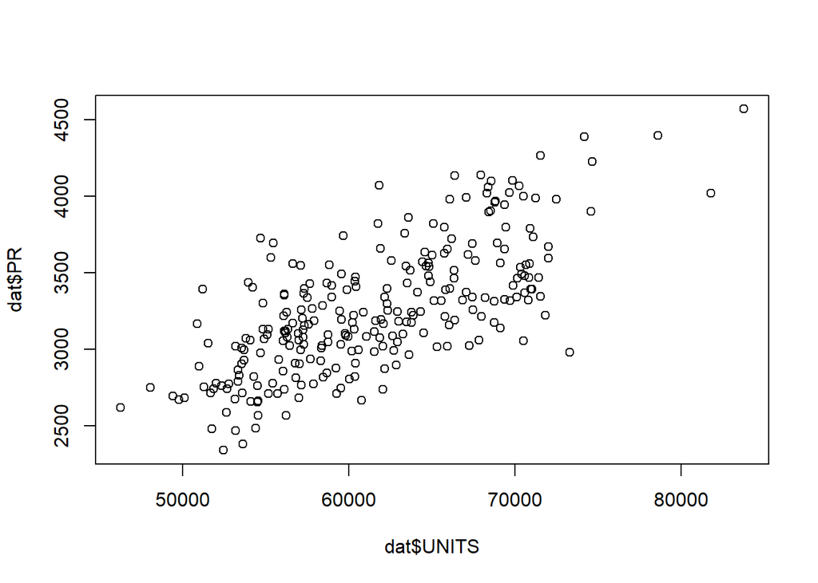

```r
plot(dat$UNITS, dat$PR)
```

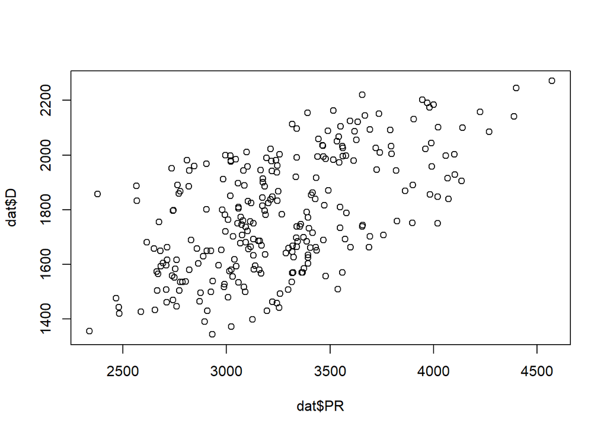

```r
plot(dat$PR, dat$D)
```

```r
cor(dat$UNITS, dat$D)
```

```
## [1] 0.5523114
```

```r
cor(dat$UNITS, dat$PR)
```

```
## [1] 0.7111293
```

```r
cor(dat$PR, dat$D)
```

```
## [1] 0.5855989
```

Using Auto Arima to fit a model

```r
#Use the auto arima to fit the model
fit = auto.arima(train, xreg = cbind(train_units, train_D, train_PR))
summary(fit)
```

```
## Series: train
## Regression with ARIMA(0,1,1)(1,1,1)[52] errors
##
## Coefficients:
##           ma1     sar1    sma1  train_units  train_D  train_PR
##       -0.5470  -0.4986  0.2079      10.3180  -3.3835   -2.9410
## s.e.   0.0939   0.4655  0.5174       0.2719   8.9482    2.9022
##
## sigma^2 estimated as 49514705:  log likelihood=-1593.06
## AIC=3200.12   AICc=3200.88   BIC=3221.42
##
## Training set error measures:
##                     ME     RMSE      MAE        MPE      MAPE      MASE
## Training set -730.4659 5955.642 4157.284 -0.1467401 0.7563141 0.1586971
##                    ACF1
## Training set 0.05929681
```

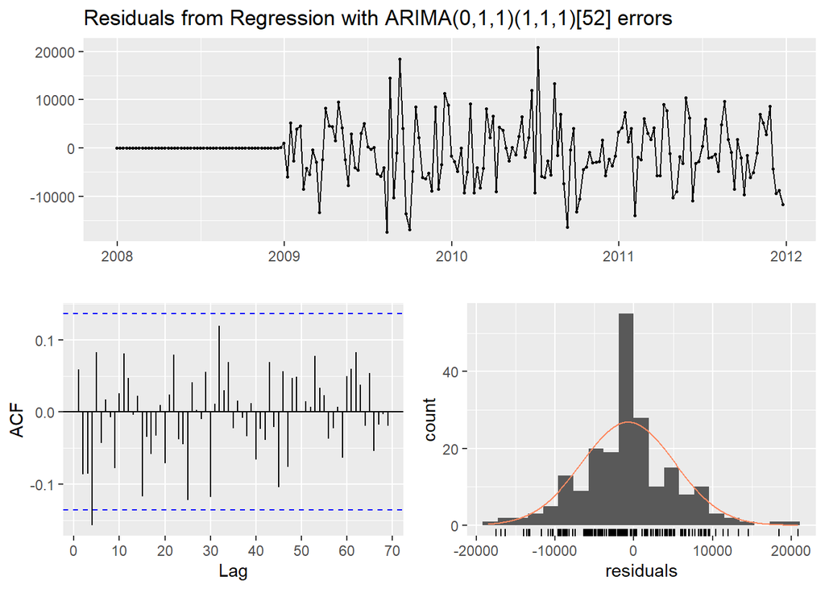

```
##
##  Ljung-Box test
##
## data:  Residuals from Regression with ARIMA(0,1,1)(1,1,1)[52] errors
## Q* = 37.996, df = 36, p-value = 0.3785
##
## Model df: 6.   Total lags used: 42
```

```r
#Use check residuals
checkresiduals(fit)
```

As per the check residuals the model is good fit (high p-value - accept null hypothesis that the model is good fit and the data are independently distributed). The residuals look normally distributed. The model looks good.

Let’s forecast using this model

```r
# Forecast using the naive function
fcast <- forecast(fit, xreg=cbind(test_units, test_D, test_PR), h=52)
```

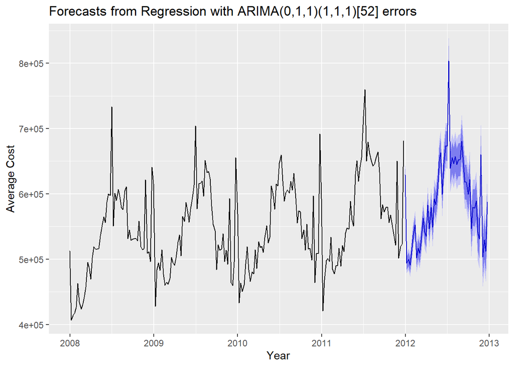

```r
autoplot(fcast) + xlab("Year") +
  ylab("Average Cost")
```

Accuracy

```r
accuracy(fcast, test)
```

```
##                     ME     RMSE      MAE         MPE      MAPE      MASE
## Training set -730.4659 5955.642 4157.284 -0.14674012 0.7563141 0.1586971
## Test set      -13.1843 9455.668 7825.199  0.01100047 1.3530761 0.2987134
##                    ACF1 Theil's U
## Training set 0.05929681        NA
## Test set     0.50812802 0.1931716
```

This model is perfoming much better than just the plain sARIMA model. The train and test RMSE are very low as compared to sARIMA model. For this model, we used the actual values of Units, D and PR for the year 2012. Let’s try to next predict the units, D and PR for the year 2012 as a univariate time series

#### Predict the regressors

Let’s try to get the forecast for Units, D and PR using Auto arima function

```r
# We need to just use the forecast from auto arima
fcast_unit = forecast(auto.arima(train_units), h=52)
fcast_D = forecast(auto.arima(train_D), h=52)
fcast_PR = forecast(auto.arima(train_PR), h=52)

fcast1 <- forecast(fit, xreg=cbind(fcast_unit$mean, fcast_D$mean, fcast_PR$mean), h=52)
```

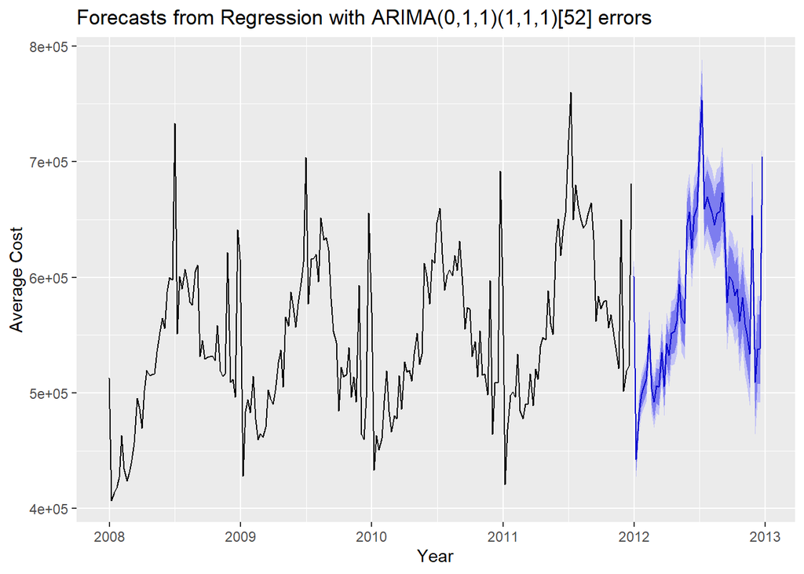

```r
autoplot(fcast1) + xlab("Year") +
  ylab("Average Cost")
```

```r
accuracy(fcast1, test)
```

```
##                     ME      RMSE       MAE        MPE      MAPE      MASE
## Training set -730.4659  5955.642  4157.284 -0.1467401 0.7563141 0.1586971
## Test set     4862.1965 34079.272 23490.459  0.7898077 4.0466358 0.8967074
##                    ACF1 Theil's U
## Training set 0.05929681        NA
## Test set     0.10624784 0.7056794
```

For this model the test RMSE has gone up by a lot, whereas the train RMSE is very low. This indicates that the model is overfitting. Let’s try to see if we can make a simple model by reducing the number of regressors.

#### Reducing the regressors

Building a regression model with just units

```r
#Use the auto arima to fit the model
fit2 = auto.arima(train, xreg = train_units)
summary(fit2)
```

```
## Series: train
## Regression with ARIMA(0,1,1)(1,1,1)[52] errors
##
## Coefficients:
##           ma1     sar1    sma1     xreg
##       -0.5679  -0.3878  0.0965  10.1878
## s.e.   0.0914   0.4493  0.4879   0.2433
##
## sigma^2 estimated as 49532713:  log likelihood=-1593.74
## AIC=3197.49   AICc=3197.89   BIC=3212.71
##
## Training set error measures:
##                     ME     RMSE      MAE        MPE      MAPE      MASE
## Training set -759.6887 5996.569 4197.708 -0.1515993 0.7646619 0.1602402
##                  ACF1
## Training set 0.071834
```

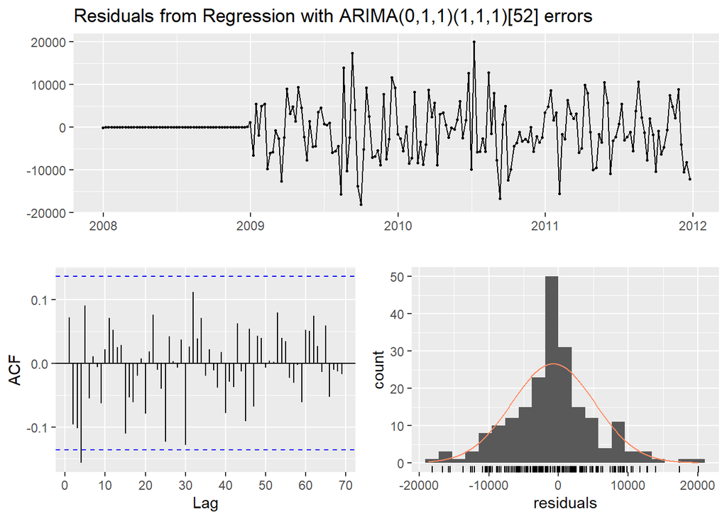

```
##
##  Ljung-Box test
##
## data:  Residuals from Regression with ARIMA(0,1,1)(1,1,1)[52] errors
## Q* = 39.96, df = 38, p-value = 0.3831
##
## Model df: 4.   Total lags used: 42
```

```r
#Use check residuals
checkresiduals(fit2)
```

This model has a lower AICC score than the model with all 3 regressors.

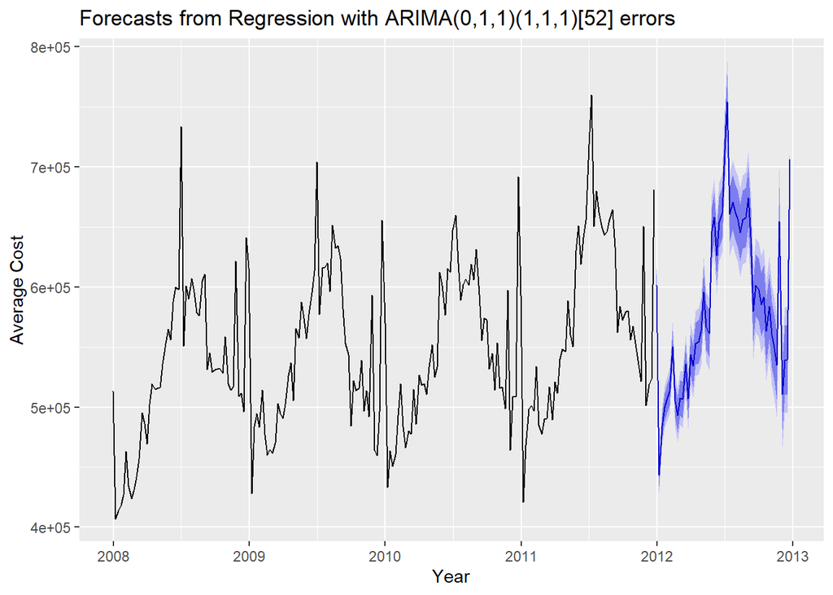

```r
fcast2 <- forecast(fit2, xreg=fcast_unit$mean, h=52)
autoplot(fcast2) + xlab("Year") +
  ylab("Average Cost")
```

```r
accuracy(fcast2, test)
```

```
##                     ME      RMSE       MAE        MPE      MAPE      MASE
## Training set -759.6887  5996.569  4197.708 -0.1515993 0.7646619 0.1602402
## Test set     3842.5923 33999.188 23233.076  0.6140708 4.0046347 0.8868823
##                   ACF1 Theil's U
## Training set 0.0718340        NA
## Test set     0.1049168 0.7043776
```

Here the Test RMSE has decreased over the model that used all 3 regressors. However this is still higher than the plain sARIMA model.

Next we will try to run the VAR model to check for the performance using all 3 regressors.

## VAR Model

Let’s first use the VARselect to determine the optimal number of lags

```r
# using the VAR() function on the combined ts
beer.ts <- ts.union(train, train_units, train_D, train_PR)


# Lets use the log of dta.ts object which contains both Cost and CPI
VAR_select = VARselect(beer.ts, type= 'both', season = 52, lag.max = 10)
VAR_select
```

```
## $selection
## AIC(n)  HQ(n)  SC(n) FPE(n)
##      5      1      1      5
##
## $criteria
##                   1            2            3            4            5
## AIC(n) 5.165836e+01 5.156926e+01 5.155904e+01 5.154424e+01 5.145352e+01
## HQ(n)  5.319100e+01 5.320946e+01 5.330679e+01 5.339955e+01 5.341638e+01
## SC(n)  5.544485e+01 5.562147e+01 5.587697e+01 5.612789e+01 5.630289e+01
## FPE(n) 2.910919e+22 2.705074e+22 2.726794e+22 2.743501e+22 2.566070e+22
##                   6            7            8            9           10
## AIC(n) 5.148227e+01 5.151002e+01 5.153942e+01 5.151191e+01 5.153226e+01
## HQ(n)  5.355269e+01 5.368799e+01 5.382494e+01 5.390499e+01 5.403289e+01
## SC(n)  5.659736e+01 5.689082e+01 5.718594e+01 5.742415e+01 5.771022e+01
## FPE(n) 2.713429e+22 2.876501e+22 3.066208e+22 3.100661e+22 3.304437e+22
```

As per the SC (BIC) output above, we need to apply VAR with lag 1, i.e. VAR(1) model.

```r
var1 <- VAR(beer.ts, p=1, type="both", season = 52)
summary(var1)
```

```
##
## VAR Estimation Results:
## =========================
## Endogenous variables: train, train_units, train_D, train_PR
## Deterministic variables: both
## Sample size: 207
## Log Likelihood: -6290.122
## Roots of the characteristic polynomial:
## 0.9324 0.6009 0.6009 0.2301
## Call:
## VAR(y = beer.ts, p = 1, type = "both", season = 52L)
##
##
## Estimation results for equation train:
## ======================================
## train = train.l1 + train_units.l1 + train_D.l1 + train_PR.l1 + const + trend + sd1 + sd2 + sd3 + sd4 + sd5 + sd6 + sd7 + sd8 + sd9 + sd10 + sd11 + sd12 + sd13 + sd14 + sd15 + sd16 + sd17 + sd18 + sd19 + sd20 + sd21 + sd22 + sd23 + sd24 + sd25 + sd26 + sd27 + sd28 + sd29 + sd30 + sd31 + sd32 + sd3…
##
##                  Estimate Std. Error t value Pr(>|t|)
## train.l1        2.233e-01  1.592e-01   1.403 0.162752
## train_units.l1  3.279e-01  1.446e+00   0.227 0.820901
## train_D.l1     -3.978e+01  2.549e+01  -1.561 0.120741
## train_PR.l1    -1.953e-01  9.218e+00  -0.021 0.983128
## const           4.439e+05  5.718e+04   7.764 1.19e-12 ***
## trend           3.062e+02  7.313e+01   4.186 4.82e-05 ***
## sd1            -1.022e+05  2.181e+04  -4.686 6.21e-06 ***
## sd2            -2.480e+05  1.767e+04 -14.036  < 2e-16 ***
## sd3            -1.792e+05  1.763e+04 -10.161  < 2e-16 ***
## sd4            -1.801e+05  1.703e+04 -10.575  < 2e-16 ***
## sd5            -1.783e+05  1.709e+04 -10.434  < 2e-16 ***
## sd6            -1.549e+05  1.655e+04  -9.356  < 2e-16 ***
## sd7            -1.592e+05  1.619e+04  -9.837  < 2e-16 ***
## sd8            -1.882e+05  1.638e+04 -11.487  < 2e-16 ***
## sd9            -1.880e+05  1.690e+04 -11.122  < 2e-16 ***
## sd10           -1.783e+05  1.718e+04 -10.378  < 2e-16 ***
## sd11           -1.767e+05  1.673e+04 -10.560  < 2e-16 ***
## sd12           -1.440e+05  1.656e+04  -8.691 5.78e-15 ***
## sd13           -1.704e+05  1.631e+04 -10.445  < 2e-16 ***
## sd14           -1.539e+05  1.658e+04  -9.284  < 2e-16 ***
## sd15           -1.510e+05  1.626e+04  -9.284  < 2e-16 ***
## sd16           -1.349e+05  1.627e+04  -8.292 5.86e-14 ***
```

[output cut: 256 more lines]

```
##
##
## Covariance matrix of residuals:
##                 train train_units train_D train_PR
## train       493503813    44521422  449574  1406074
## train_units  44521422     4343109   42518   146407
## train_D        449574       42518    2917     2870
## train_PR      1406074      146407    2870    32281
##
## Correlation matrix of residuals:
##              train train_units train_D train_PR
## train       1.0000      0.9617  0.3747   0.3523
## train_units 0.9617      1.0000  0.3777   0.3910
## train_D     0.3747      0.3777  1.0000   0.2958
## train_PR    0.3523      0.3910  0.2958   1.0000
```

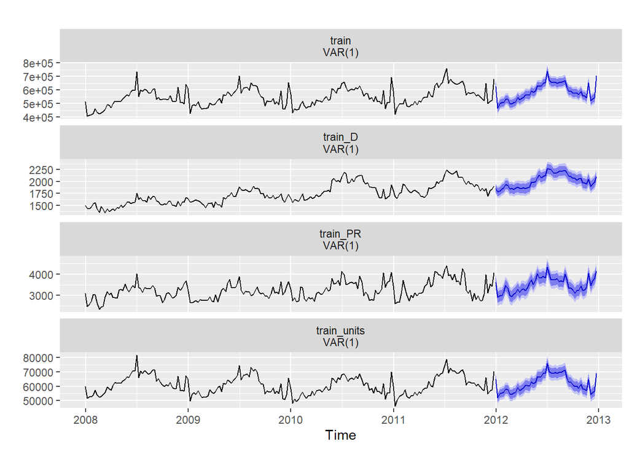

```r
# Using Forecast
var_fcast = forecast(var1, h=52)
autoplot(var_fcast)
```

```r
var_fcast$forecast$train
```

```
##          Point Forecast    Lo 80    Hi 80    Lo 95    Hi 95
## 2011.997       624094.0 595624.4 652563.6 580553.5 667634.5
## 2012.016       466558.6 437319.9 495797.3 421841.8 511275.4
## 2012.036       499518.2 470155.7 528880.7 454612.2 544424.2
## 2012.055       506333.3 476907.9 535758.8 461331.0 551335.7
## 2012.074       508302.9 478838.6 537767.1 463241.1 553364.6
## 2012.093       531576.2 502085.8 561066.6 486474.6 576677.8
## 2012.113       530696.4 501186.8 560206.0 485565.3 575827.4
## 2012.132       502325.7 472800.8 531850.6 457171.3 547480.1
## 2012.151       498866.5 469328.9 528404.0 453692.7 544040.3
## 2012.170       507284.4 477736.0 536832.7 462094.1 552474.7
## 2012.190       512427.6 482870.0 541985.2 467223.1 557632.1
## 2012.209       545779.3 516213.6 575345.0 500562.5 590996.1
## 2012.228       527356.8 497784.1 556929.4 482129.3 572584.3
## 2012.247       539927.7 510349.0 569506.4 494691.0 585164.5
## 2012.266       546602.4 517018.4 576186.4 501357.6 591847.2
## 2012.286       564218.0 534629.4 593806.6 518966.1 609469.8
## 2012.305       565426.9 535834.3 595019.4 520168.9 610684.8
## 2012.324       562800.3 533204.3 592396.3 517537.1 608063.5
## 2012.343       593039.1 563440.1 622638.2 547771.3 638307.0
## 2012.363       582020.3 552418.7 611622.0 536748.5 627292.2
## 2012.382       593324.0 563720.1 622927.9 548048.7 638599.3
## 2012.401       632504.4 602898.5 662110.3 587226.1 677782.7
## 2012.420       628448.1 598840.5 658055.7 583167.1 673729.1
## 2012.440       627255.0 597645.9 656864.1 581971.7 672538.2
## 2012.459       649889.4 620278.9 679499.8 604604.1 695174.6
## 2012.478       656736.9 627125.4 686348.5 611450.0 702023.9
## 2012.497       737721.9 708109.3 767334.4 692433.4 783010.3
## 2012.516       673898.4 644285.0 703511.8 628608.6 719188.1
## 2012.536       658625.4 629011.3 688239.5 613334.5 703916.3
## 2012.555       655530.8 625916.0 685145.6 610238.9 700822.7
## 2012.574       659631.4 630016.0 689246.7 614338.6 704924.1
## 2012.593       648702.7 619086.9 678318.5 603409.2 693996.2
## 2012.613       655246.7 625630.5 684863.0 609952.6 700540.9
## 2012.632       655179.5 625562.9 684796.2 609884.8 700474.3
## 2012.651       661902.5 632285.5 691519.4 616607.3 707197.7
## 2012.670       669149.3 639532.1 698766.6 623853.7 714445.0
## 2012.690       621512.9 591895.4 651130.3 576216.9 666808.9
## 2012.709       590558.1 560940.4 620175.7 545261.7 635854.4
## 2012.728       594201.1 564583.3 623818.9 548904.5 639497.7
## 2012.747       576704.4 547086.4 606322.4 531407.6 622001.2
## 2012.766       577651.6 548033.5 607269.8 532354.6 622948.7
## 2012.786       579198.9 549580.6 608817.1 533901.6 624496.1
## 2012.805       564998.3 535380.0 594616.7 519701.0 610295.7
## 2012.824       591094.4 561475.9 620712.9 545796.9 636391.9
## 2012.843       556645.0 527026.4 586263.5 511347.3 601942.6
## 2012.863       556515.6 526897.0 586134.2 511217.8 601813.3
## 2012.882       543559.7 513941.0 573178.3 498261.8 588857.5
## 2012.901       651832.7 622214.0 681451.4 606534.8 697130.6
## 2012.920       521137.0 491518.2 550755.8 475839.0 566435.0
## 2012.940       536172.9 506554.1 565791.7 490874.8 581470.9
## 2012.959       542409.3 512790.5 572028.2 497111.2 587707.4
## 2012.978       703678.9 674060.0 733297.7 658380.7 748977.0
```

```r
#Accuracy
accuracy(var_fcast$forecast$train, test)
```

```
##                        ME     RMSE      MAE        MPE     MAPE      MASE
## Training set 2.251069e-12 18910.62 13758.67 -0.1073425 2.499457 0.5252133
## Test set     3.343253e+03 36847.98 24150.33  0.3965807 4.044999 0.9218968
##                     ACF1 Theil's U
## Training set -0.05279289        NA
## Test set     -0.12979856 0.7378414
```

The VAR Forecast error is much higher than Regression with ARMA error. Let’s just use one regressor on the VAR model

```r
# using the VAR() function on the combined ts
beer.ts1 <- ts.union(train, train_units)


# Lets use the log of dta.ts object which contains both Cost and CPI
VAR_select1 = VARselect(beer.ts, type= 'both', season = 52, lag.max = 10)
VAR_select1
```

```
## $selection
## AIC(n)  HQ(n)  SC(n) FPE(n)
##      5      1      1      5
##
## $criteria
##                   1            2            3            4            5
## AIC(n) 5.165836e+01 5.156926e+01 5.155904e+01 5.154424e+01 5.145352e+01
## HQ(n)  5.319100e+01 5.320946e+01 5.330679e+01 5.339955e+01 5.341638e+01
## SC(n)  5.544485e+01 5.562147e+01 5.587697e+01 5.612789e+01 5.630289e+01
## FPE(n) 2.910919e+22 2.705074e+22 2.726794e+22 2.743501e+22 2.566070e+22
##                   6            7            8            9           10
## AIC(n) 5.148227e+01 5.151002e+01 5.153942e+01 5.151191e+01 5.153226e+01
## HQ(n)  5.355269e+01 5.368799e+01 5.382494e+01 5.390499e+01 5.403289e+01
## SC(n)  5.659736e+01 5.689082e+01 5.718594e+01 5.742415e+01 5.771022e+01
## FPE(n) 2.713429e+22 2.876501e+22 3.066208e+22 3.100661e+22 3.304437e+22
```

```r
var2 <- VAR(beer.ts1, p=1, type="both", season = 52)
summary(var2)
```

```
##
## VAR Estimation Results:
## =========================
## Endogenous variables: train, train_units
## Deterministic variables: both
## Sample size: 207
## Log Likelihood: -3910.309
## Roots of the characteristic polynomial:
## 0.9127 0.2279
## Call:
## VAR(y = beer.ts1, p = 1, type = "both", season = 52L)
##
##
## Estimation results for equation train:
## ======================================
## train = train.l1 + train_units.l1 + const + trend + sd1 + sd2 + sd3 + sd4 + sd5 + sd6 + sd7 + sd8 + sd9 + sd10 + sd11 + sd12 + sd13 + sd14 + sd15 + sd16 + sd17 + sd18 + sd19 + sd20 + sd21 + sd22 + sd23 + sd24 + sd25 + sd26 + sd27 + sd28 + sd29 + sd30 + sd31 + sd32 + sd33 + sd34 + sd35 + sd36 + sd…
##
##                  Estimate Std. Error t value Pr(>|t|)
## train.l1        1.456e-01  1.515e-01   0.961 0.338069
## train_units.l1  9.479e-01  1.388e+00   0.683 0.495582
## const           3.871e+05  4.423e+04   8.752 3.73e-15 ***
## trend           2.303e+02  5.535e+01   4.162 5.27e-05 ***
## sd1            -1.027e+05  2.183e+04  -4.704 5.69e-06 ***
## sd2            -2.480e+05  1.743e+04 -14.227  < 2e-16 ***
## sd3            -1.797e+05  1.674e+04 -10.737  < 2e-16 ***
## sd4            -1.802e+05  1.607e+04 -11.213  < 2e-16 ***
## sd5            -1.796e+05  1.598e+04 -11.239  < 2e-16 ***
## sd6            -1.571e+05  1.592e+04  -9.869  < 2e-16 ***
## sd7            -1.636e+05  1.578e+04 -10.362  < 2e-16 ***
## sd8            -1.915e+05  1.579e+04 -12.129  < 2e-16 ***
## sd9            -1.883e+05  1.598e+04 -11.781  < 2e-16 ***
## sd10           -1.790e+05  1.602e+04 -11.174  < 2e-16 ***
## sd11           -1.763e+05  1.591e+04 -11.080  < 2e-16 ***
## sd12           -1.443e+05  1.586e+04  -9.095 4.89e-16 ***
## sd13           -1.710e+05  1.580e+04 -10.819  < 2e-16 ***
## sd14           -1.538e+05  1.578e+04  -9.751  < 2e-16 ***
## sd15           -1.501e+05  1.578e+04  -9.511  < 2e-16 ***
## sd16           -1.344e+05  1.579e+04  -8.508 1.57e-14 ***
## sd17           -1.377e+05  1.594e+04  -8.639 7.28e-15 ***
## sd18           -1.407e+05  1.595e+04  -8.820 2.50e-15 ***
```

[output cut: 106 more lines]

```
## Residual standard error: 2098 on 152 degrees of freedom
## Multiple R-Squared: 0.9237,  Adjusted R-squared: 0.8966
## F-statistic: 34.09 on 54 and 152 DF,  p-value: < 2.2e-16
##
##
##
## Covariance matrix of residuals:
##                 train train_units
## train       495241489    44902144
## train_units  44902144     4399596
##
## Correlation matrix of residuals:
##              train train_units
## train       1.0000      0.9619
## train_units 0.9619      1.0000
```

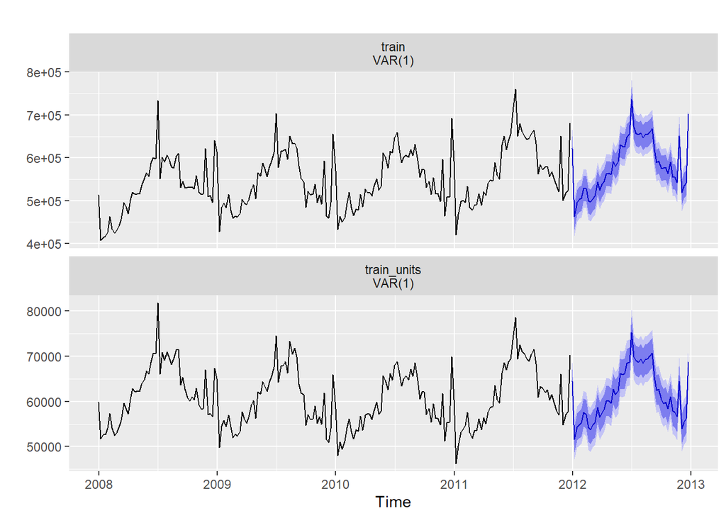

```r
# Using Forecast
var_fcast1 = forecast(var2, h=52)
autoplot(var_fcast1)
```

```r
var_fcast1$forecast$train
```

```
##          Point Forecast    Lo 80    Hi 80    Lo 95    Hi 95
## 2011.997       621913.4 593393.8 650433.1 578296.3 665530.5
## 2012.016       462721.4 433438.7 492004.0 417937.5 507505.3
## 2012.036       495853.4 466516.3 525190.5 450986.2 540720.6
## 2012.055       503077.7 473727.3 532428.1 458190.1 547965.3
## 2012.074       505394.3 476035.0 534753.7 460493.1 550295.6
## 2012.093       528925.4 499558.7 558292.0 484013.0 573837.8
## 2012.113       528234.1 498861.4 557606.7 483312.5 573155.7
## 2012.132       500004.7 470627.0 529382.3 455075.4 544933.9
## 2012.151       496655.7 467273.8 526037.5 451720.0 541591.3
## 2012.170       505163.5 475778.2 534548.8 460222.6 550104.5
## 2012.190       510383.4 480995.2 539771.6 465438.0 555328.8
## 2012.209       543802.7 514412.1 573193.3 498853.6 588751.8
## 2012.228       525441.6 496049.0 554834.2 480489.4 570393.7
## 2012.247       538069.4 508675.0 567463.7 493114.6 583024.1
## 2012.266       544797.3 515401.6 574193.0 499840.5 589754.2
## 2012.286       562463.3 533066.5 591860.2 517504.7 607422.0
## 2012.305       563720.1 534322.3 593117.9 518760.0 608680.2
## 2012.324       561139.2 531740.6 590537.8 516177.9 606100.5
## 2012.343       591421.5 562022.2 620820.8 546459.2 636383.9
## 2012.363       580444.3 551044.4 609844.1 535481.0 625407.5
## 2012.382       591787.5 562387.2 621187.8 546823.6 636751.4
## 2012.401       631005.7 601604.9 660406.4 586041.1 675970.2
## 2012.420       626985.4 597584.3 656386.4 582020.3 671950.4
## 2012.440       625826.5 596425.2 655227.8 580861.1 670791.9
## 2012.459       648493.5 619091.9 677895.0 603527.7 693459.2
## 2012.478       655372.0 625970.3 684773.8 610406.0 700338.1
## 2012.497       736386.4 706984.5 765788.3 691420.1 781352.7
## 2012.516       672590.9 643188.8 701992.9 627624.4 717557.3
## 2012.536       657344.4 627942.3 686746.5 612377.7 702311.1
## 2012.555       654274.9 624872.7 683677.1 609308.1 699241.7
## 2012.574       658399.3 628997.0 687801.6 613432.4 703366.2
## 2012.593       647493.2 618090.8 676895.5 602526.2 692460.2
## 2012.613       654058.6 624656.2 683461.0 609091.5 699025.6
## 2012.632       654011.6 624609.1 683414.0 609044.4 698978.7
## 2012.651       660753.6 631351.1 690156.1 615786.4 705720.8
## 2012.670       668018.5 638616.0 697421.0 623051.2 712985.8
## 2012.690       620399.1 590996.5 649801.6 575431.8 665366.4
## 2012.709       589460.3 560057.8 618862.9 544493.0 634427.7
## 2012.728       593118.6 563716.0 622521.1 548151.2 638085.9
## 2012.747       575636.2 546233.6 605038.7 530668.8 620603.5
## 2012.766       576596.9 547194.3 605999.5 531629.5 621564.3
## 2012.786       578156.9 548754.3 607559.5 533189.5 623124.3
## 2012.805       563968.3 534565.7 593371.0 519000.9 608935.8
## 2012.824       590075.7 560673.1 619478.3 545108.3 635043.1
## 2012.843       555636.9 526234.3 585039.5 510669.5 600604.4
## 2012.863       555517.6 526114.9 584920.2 510550.1 600485.0
## 2012.882       542571.1 513168.4 571973.7 497603.6 587538.5
## 2012.901       650853.0 621450.3 680255.6 605885.5 695820.4
## 2012.920       520165.6 490763.0 549568.3 475198.1 565133.1
## 2012.940       535209.3 505806.7 564612.0 490241.8 580176.8
## 2012.959       541453.2 512050.5 570855.8 496485.7 586420.6
## 2012.978       702729.6 673327.0 732132.3 657762.2 747697.1
```

```r
#Accuracy
accuracy(var_fcast1$forecast$train, test)
```

```
##                         ME     RMSE      MAE        MPE     MAPE      MASE
## Training set -3.091801e-12 19069.76 13919.38 -0.1104270 2.529439 0.5313481
## Test set      4.935467e+03 37211.38 24725.03  0.6751535 4.143766 0.9438351
##                     ACF1 Theil's U
## Training set -0.04603902        NA
## Test set     -0.12064666 0.7447313
```

This model is performing worse that the VAR model with all 3 regressors.